# Assignment 6

Tanush

19/10/2024

```r
# Set a CRAN mirror
options(repos = c(CRAN = "https://cran.r-project.org"))

install.packages("pacman")
#install.packages("readr")
library(pacman)
pacman::p_load(pacman, dplyr, forecast, fpp, fpp2, readr)

data <- read.csv("C:/Users/tanus/Downloads/BF assign 6/flightVolume.csv")

head(data)
```

```
##   X permanent reslong vislong resshort visshort
## 1 1      2.17    7.39    1.87     75.8     66.2
## 2 2      2.06    5.13    1.42     54.7     49.4
## 3 3      2.66    6.35    1.67     85.0     46.8
## 4 4      2.32    5.64    1.42     74.6     41.0
## 5 5      2.75    6.73    1.77    103.9     43.0
## 6 6      2.00    5.17    1.42     82.0     28.4
```

```r
str(data)
```

```
## 'data.frame':    498 obs. of  6 variables:
##  $ X        : int  1 2 3 4 5 6 7 8 9 10 ...
##  $ permanent: num  2.17 2.06 2.66 2.32 2.75 2 2.16 2.26 1.84 2.04 ...
##  $ reslong  : num  7.39 5.13 6.35 5.64 6.73 5.17 5.56 6 4.49 4.22 ...
##  $ vislong  : num  1.87 1.42 1.67 1.42 1.77 1.42 1.37 1.65 1.27 1.29 ...
##  $ resshort : num  75.8 54.7 85 74.6 103.9 ...
##  $ visshort : num  66.2 49.4 46.8 41 43 28.4 30 41.5 38.6 39 ...
```

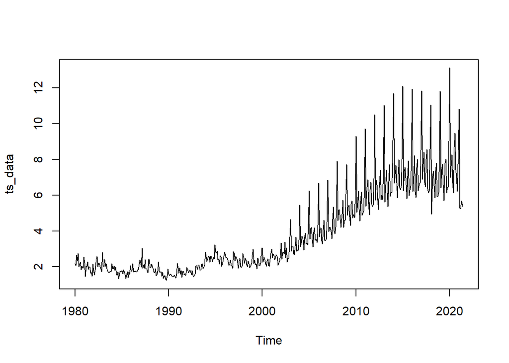

```r
#1. Create Timeseries

ts_data = ts(data$permanent, frequency = 12, start = c(1980,1))

plot(ts_data)
```

2. Verify how much history to include in your analysis. Looking at the time series plot, trend change is significant at around 300, so it makes sense to focus more on data after that point. Keeping too much older data might obscure recent patterns if conditions have changed.
3. Hypothesize if the dataset has trend, seasonality, or both. The time series likely contains both a trend and some form of seasonality. The trend is a gradual increase over time, while the repeating oscillations, particularly after point 300, suggest possible seasonality or cyclical patterns. The variability (amplitude of oscillations) also seems to increase over time, which might point to non-constant seasonality

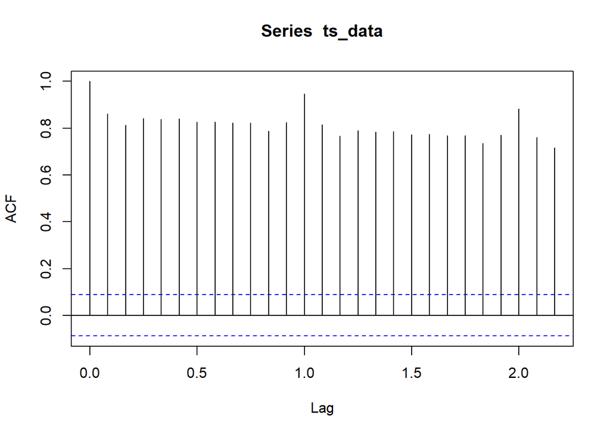

```r
# 4. Verify using Acf

acf(ts_data)
```

```r
# Based on the ACF, it seems there is a seasonal pattern in the data. The regularity and magnitude of spikes suggest that the series might have repeating cycles.
```

5. Verify using decomposition The decomposition analysis was performed using a multiplicative model, which broke the time series into three components: Trend: A visible long-term movement, confirming the presence of a trend. Seasonality: The repeating cyclical pattern, confirming that the data exhibits seasonal behavior. Residual (Noise): Random fluctuations that are not explained by trend or seasonality.

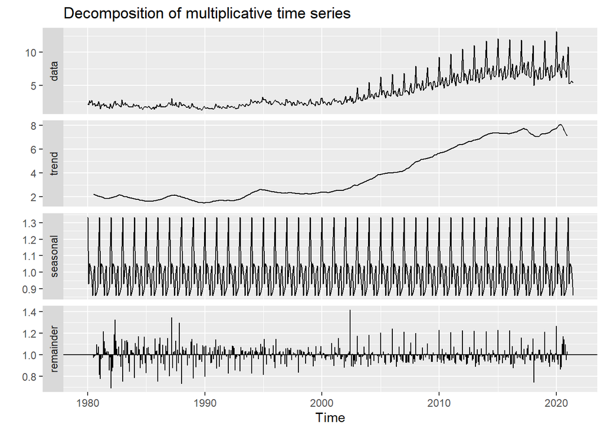

```r
decomposed <- decompose(ts_data, type = "multiplicative")
autoplot(decomposed)
```

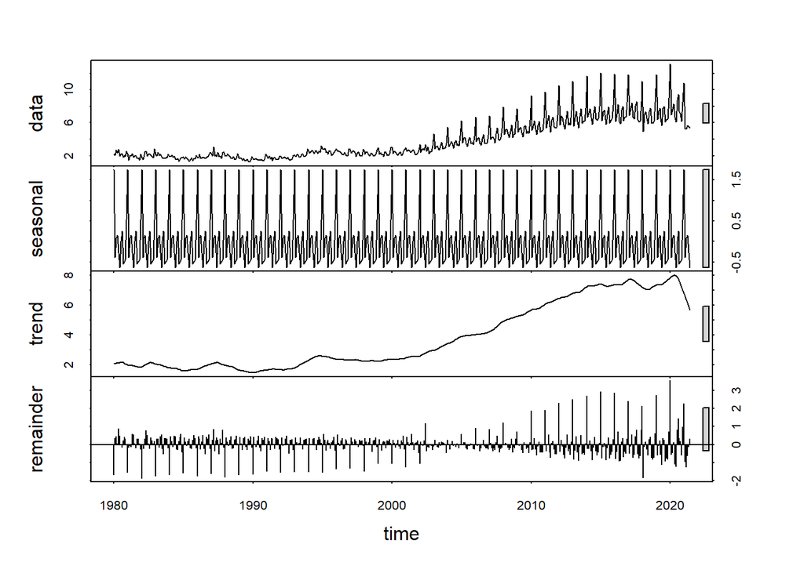

```r
stl_decomp <- stl(ts_data,s.window ="periodic")
plot(stl_decomp)
```

```r
attributes(stl_decomp)
```

```
## $names
## [1] "time.series" "weights"     "call"        "win"         "deg"
## [6] "jump"        "inner"       "outer"
##
## $class
## [1] "stl"
```

```r
# Lets print out a seasonal adjustment
seasadj(stl_decomp)
```

[output not shown]

[output cut: 114 more lines]

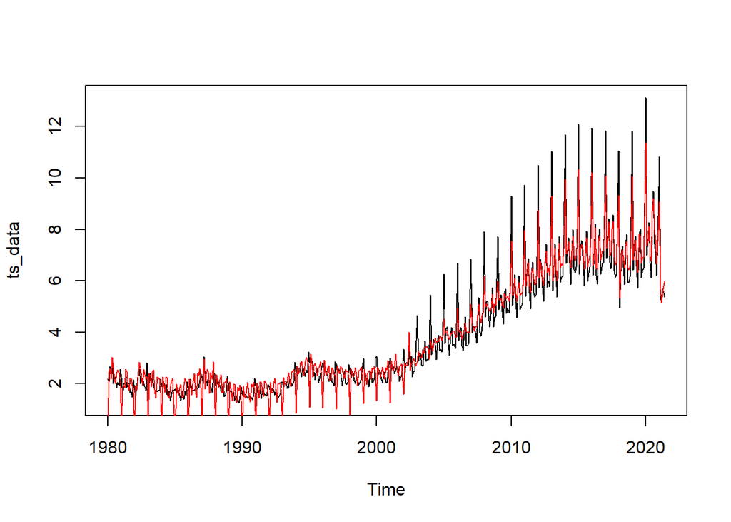

```r
# Plot a line on the graph
plot(ts_data)
lines(seasadj(stl_decomp), col="Red")
```

```r
# Default period forecast
f_stl <- forecast(stl_decomp)
# you can pass the # of period
f_stl <- forecast(stl_decomp,h=15)
f_stl
```

```
##          Point Forecast    Lo 80    Hi 80    Lo 95     Hi 95
## Jul 2021       7.058563 6.143363 7.973762 5.658886  8.458240
## Aug 2021       7.293373 6.374156 8.212589 5.887553  8.699193
## Sep 2021       6.469891 5.546418 7.393363 5.057561  7.882220
## Oct 2021       6.514635 5.586663 7.442608 5.095424  7.933847
## Nov 2021       6.550844 5.618123 7.483565 5.124370  7.977318
## Dec 2021       7.516390 6.578668 8.454112 6.082268  8.950512
## Jan 2022       8.716214 7.773234 9.659193 7.274051 10.158376
## Feb 2022       6.572062 5.623566 7.520558 5.121462  8.022662
## Mar 2022       7.018623 6.064347 7.972900 5.559183  8.478063
## Apr 2022       7.070884 6.110562 8.031207 5.602198  8.539571
## May 2022       6.647907 5.681270 7.614544 5.169563  8.126251
## Jun 2022       6.270605 5.297382 7.243828 4.782189  7.759021
## Jul 2022       6.891982 5.911900 7.872064 5.393076  8.390888
## Aug 2022       7.126792 6.139577 8.114008 5.616976  8.636608
## Sep 2022       6.303310 5.308684 7.297936 4.782161  7.824459
```

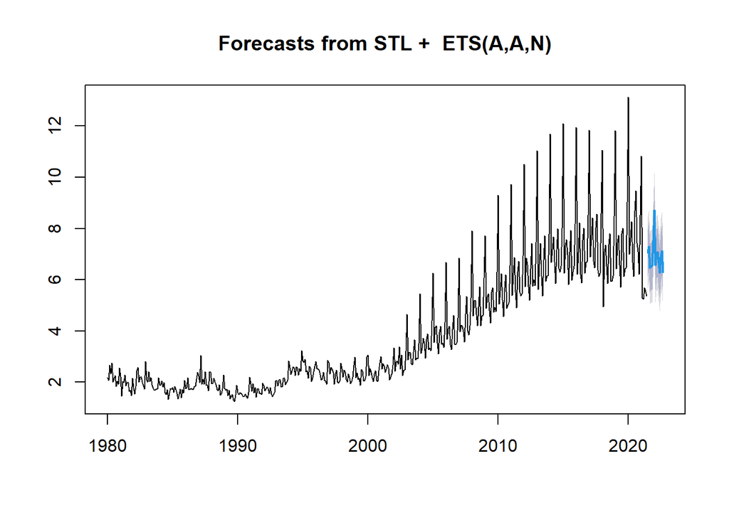

```r
plot(f_stl)
```

```r
# There is more than one way to do things
decomp_elec <- decompose(ts_data)

# Each one shows different attributes
attributes(decomp_elec)
```

```
## $names
## [1] "x"        "seasonal" "trend"    "random"   "figure"   "type"
##
## $class
## [1] "decomposed.ts"
```

```r
seasadj(decomp_elec)
```

[output not shown]

[output cut: 71 more lines]

6. Choose an accuracy measure Mean Absolute Percentage Error (MAPE) would be a good choice for this dataset. It provides a clear, relative measure of forecast errors, making it easy to understand how far off predictions are in percentage terms.
7. Create a forecast model for the next 12 months. Include Naive, Average, Exponential Smoothing, HoltWinters, and Decomposition (both types).

```r
start(ts_data)  # Check the start period of the time series
```

```
## [1] 1980    1
```

```r
end(ts_data)    # Check the end period of the time series
```

```
## [1] 2021    6
```

```r
frequency(ts_data)  # Check if it is monthly (should return 12)
```

```
## [1] 12
```

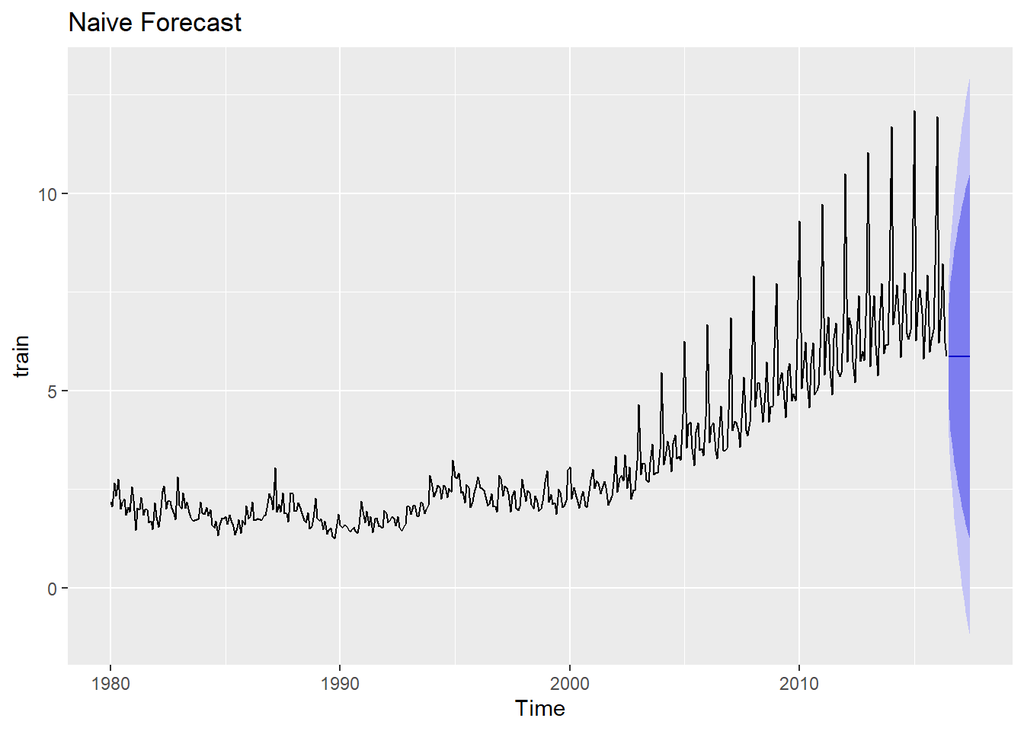

```r
# Assuming you want to use all data except the last 12 months for training
# Use data up to June 2016 for training (training data ends at June 2016)
train <- window(ts_data, end = c(2016, 6))

# Use data from July 2016 to June 2017 for testing
test <- window(ts_data, start = c(2016, 7))  # The last 12 months for test

# 1. Naive model
naive_model <- naive(train, h = 12)
naive_forecast <- forecast(naive_model, h = 12)

# 2. Average method
mean_forecast <- meanf(train, h = 12)

# 3. Exponential Smoothing
exp_smooth_model <- ses(train, h = 12)
exp_smooth_forecast <- forecast(exp_smooth_model, h = 12)

# 4. Holt-Winters Additive Model
hw_add_model <- hw(train, seasonal = "additive", h = 12)
hw_add_forecast <- forecast(hw_add_model)

# 5. Holt-Winters Multiplicative Model
hw_mult_model <- hw(train, seasonal = "multiplicative", h = 12)
hw_mult_forecast <- forecast(hw_mult_model)

# 6. Decomposition Forecast
# Decompose the time series
decomposed_add <- decompose(ts_data, type = "additive")
decomposed_mult <- decompose(ts_data, type = "multiplicative")

# Remove NA values from the trend component
trend_add <- na.omit(decomposed_add$trend)
trend_mult <- na.omit(decomposed_mult$trend)

# Forecast based on decomposition (seasonal naive for decomposition)
decomp_add_forecast <- naive(trend_add, h = 12)
decomp_mult_forecast <- naive(trend_mult, h = 12)


# Plot forecasts
autoplot(naive_forecast) + ggtitle("Naive Forecast")
```

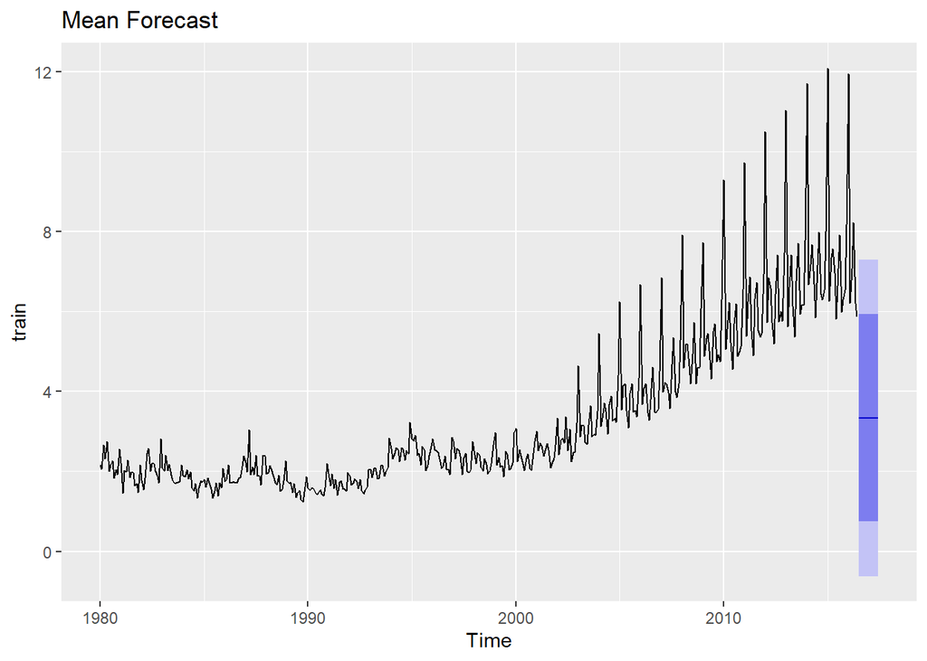

```r
autoplot(mean_forecast) + ggtitle("Mean Forecast")
```

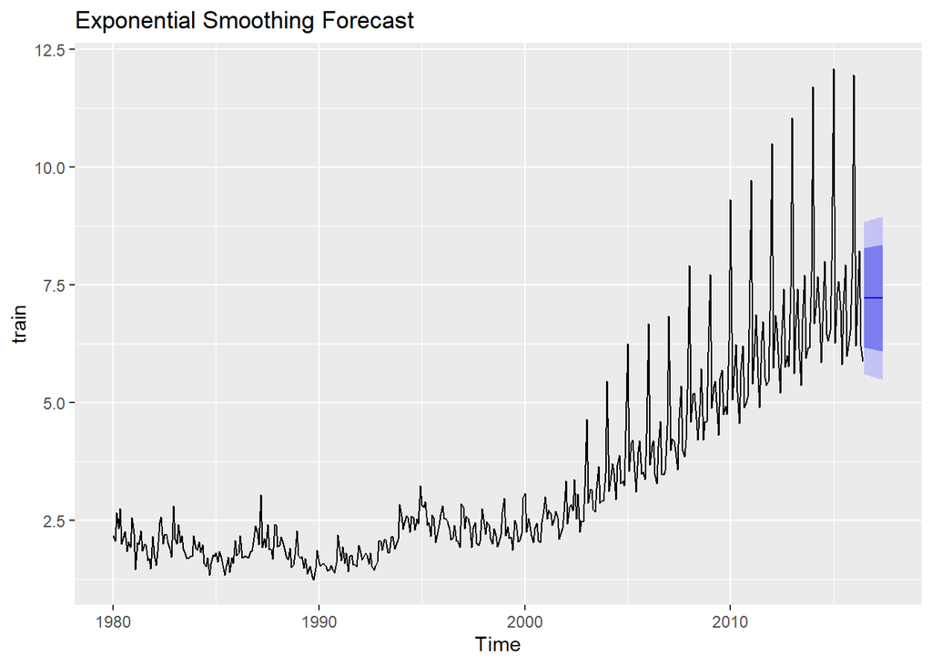

```r
autoplot(exp_smooth_forecast) + ggtitle("Exponential Smoothing Forecast")
```

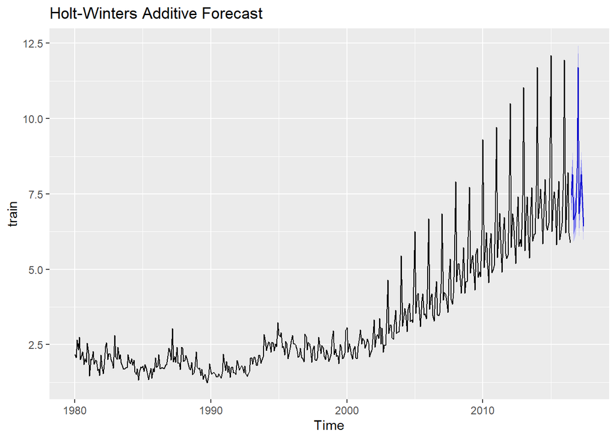

```r
autoplot(hw_add_forecast) + ggtitle("Holt-Winters Additive Forecast")
```

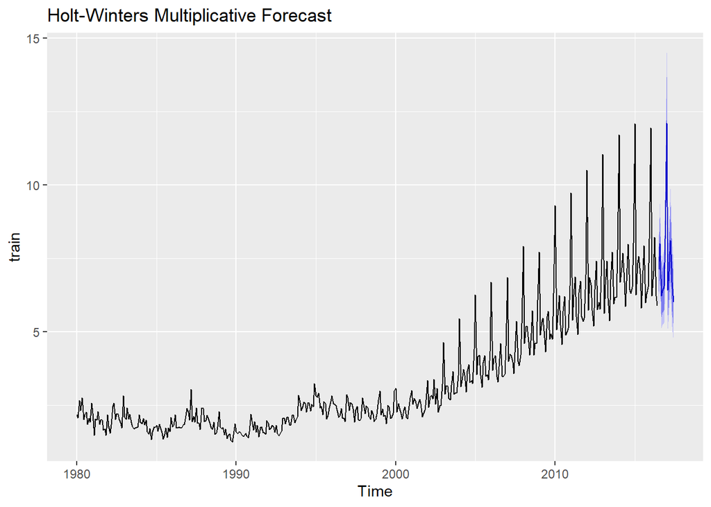

```r
autoplot(hw_mult_forecast) + ggtitle("Holt-Winters Multiplicative Forecast")
```

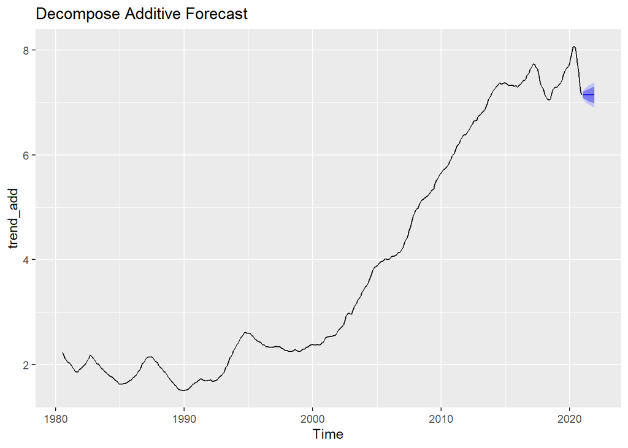

```r
autoplot(decomp_add_forecast) + ggtitle("Decompose Additive Forecast")
```

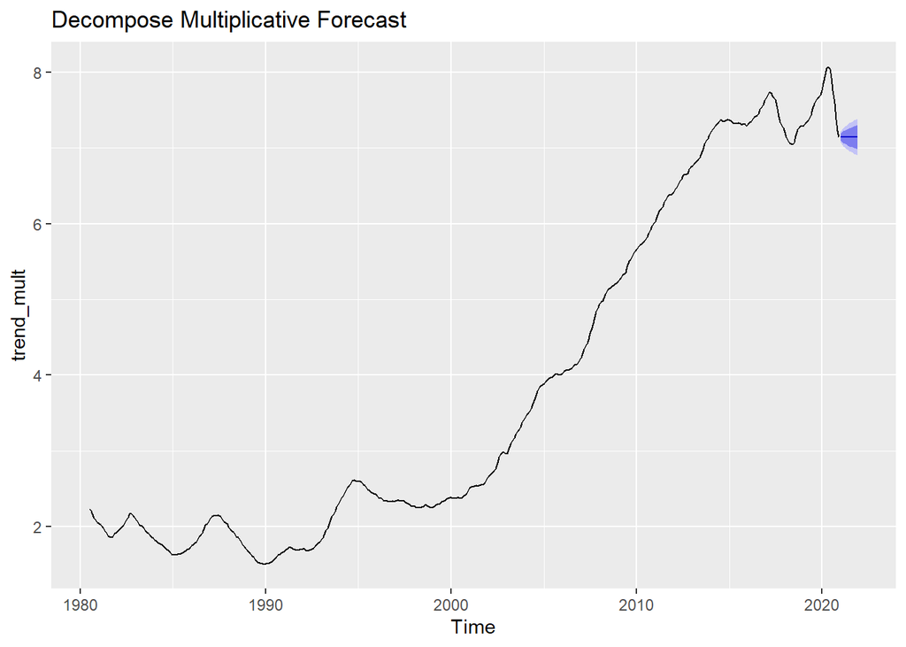

```r
autoplot(decomp_mult_forecast) + ggtitle("Decompose Multiplicative Forecast")
```